# Filling in the Counterfactual: A Tutorial on Matrix Completion Methods for Causal Inference in Panel Data

Yidong Yang

2026-05-20

# Abstract

Panel data—repeated observations on multiple units over time—arise throughout the social sciences, economics, and public health. When a subset of units adopts a treatment at some point in time, researchers want to estimate the causal effect of that treatment. The fundamental challenge is that we never observe the *counterfactual* outcome: what would have happened to a treated unit had it not been treated. This tutorial introduces matrix completion as a machine-learning approach to this missing data problem. By assuming that the matrix of untreated potential outcomes has approximately low-rank structure, we can impute the missing counterfactuals using nuclear norm minimization and the soft-impute algorithm. I first review the potential outcomes framework for panel data and briefly connect matrix completion to classical approaches such as difference-in-differences and synthetic control. I then derive the nuclear norm estimator, explain the soft-impute algorithm, and discuss cross-validation with block hold-outs. Using a reproducible simulation, I compare matrix completion to difference-in-differences, synthetic control via re-weighting, and interactive fixed effects in terms of counterfactual recovery and average treatment effect estimation. The tutorial highlights when low-rank imputation improves on traditional methods and where it can fail, including sensitivity to rank misspecification, difficulty with formal inference, and dependence on the missingness pattern.

# Introduction

Estimating the causal effects of policies, programs, and interventions is central to empirical research. Panel data—where we observe $N$ units over $T$ time periods—offer a rich structure for this task. A common setting is *staggered adoption*: different units begin treatment at different times, and we want to know the effect of treatment on the treated units.

The fundamental problem of causal inference is that we never observe both potential outcomes for the same unit at the same time. For a treated unit in a post-treatment period, the outcome under no treatment—the *counterfactual*—is missing. The entire enterprise of causal panel data analysis can therefore be reframed as a structured missing data problem: how do we fill in the unobserved entries of the $N \times T$ matrix of untreated potential outcomes?

Classical methods each impose a specific structure to solve this problem. Difference-in-differences (DiD) assumes parallel trends: absent treatment, treated and control units would have followed the same time path. Synthetic control constructs a weighted combination of control units to approximate each treated unit’s counterfactual. Interactive fixed effects models posit that outcomes are generated by a low-dimensional factor structure.

Matrix completion, as introduced to the causal inference literature by Athey, Bayati, Doudchenko, Imbens, and Khosravi (2021), provides a unifying perspective. It treats the problem explicitly as matrix completion under a low-rank assumption, using nuclear norm regularization—the convex relaxation of rank minimization—to impute counterfactuals. This approach nests DiD and synthetic control as special cases and connects naturally to the interactive fixed effects literature.

This tutorial walks through the method from causal foundations to implementation. The reader should come away understanding *why* matrix completion is a natural tool for causal panel data, *how* to implement it, and *when* it helps or fails relative to alternatives.

# Setup: Potential Outcomes in Panel Data

## Notation

Consider $N$ units indexed by $i = 1, \dots, N$ observed over $T$ time periods indexed by $t = 1, \dots, T$. Let $W_{it} \in \{0, 1\}$ denote the treatment indicator: $W_{it} = 1$ if unit $i$ is treated at time $t$, and 0 otherwise.

Each unit-time pair has two *potential outcomes*:

- $Y_{it}(0)$: the outcome unit $i$ would realize at time $t$ under no treatment.
- $Y_{it}(1)$: the outcome under treatment.

The observed outcome is:
$$Y_{it} = W_{it} \cdot Y_{it}(1) + (1 - W_{it}) \cdot Y_{it}(0).$$

The individual treatment effect is $\tau_{it} = Y_{it}(1) - Y_{it}(0)$. Since we never observe both potential outcomes simultaneously, $\tau_{it}$ is not directly identifiable for any single $(i, t)$.

## The Estimand

We focus on the *average treatment effect on the treated* (ATT):
$$\tau_{\text{ATT}} = \frac{1}{|\mathcal{M}|} \sum_{(i,t) \in \mathcal{M}}
\left[ Y_{it}(1) - Y_{it}(0) \right],$$
where $\mathcal{M} = \{(i, t) : W_{it} = 1\}$ is the set of treated cells. Since $Y_{it}(1)$ is observed for treated cells, the problem reduces to estimating $Y_{it}(0)$ for $(i, t) \in \mathcal{M}$.

## The Key Insight

Define the $N \times T$ matrix of untreated potential outcomes:
$$\boldsymbol{Y}(0) = \begin{bmatrix} Y_{11}(0) & \cdots &
Y_{1T}(0) \\ \vdots & \ddots & \vdots \\ Y_{N1}(0) & \cdots
& Y_{NT}(0) \end{bmatrix}.$$

For control cells $\mathcal{O} = \{(i, t) : W_{it} = 0\}$, we observe $Y_{it}(0)$ directly. For treated cells $\mathcal{M}$, these entries are missing. **Estimating the ATT is equivalent to completing the missing entries of the matrix $\boldsymbol{Y}(0)$.**

# Classical Approaches (Brief Review)

Before introducing matrix completion, it helps to see what existing methods assume about $\boldsymbol{Y}(0)$.

## Difference-in-Differences

DiD assumes the *parallel trends* condition: absent treatment, the change in outcomes over time would be the same for treated and control units. This is equivalent to assuming:
$$Y_{it}(0) = \alpha_i + \gamma_t + \varepsilon_{it},$$
an additive model with unit fixed effects $\alpha_i$ and time fixed effects $\gamma_t$. In matrix terms, $\boldsymbol{Y}(0)$ is approximated by a rank-2 structure (a column of ones times a row vector, plus a row of ones times a column vector).

## Synthetic Control

The synthetic control method (Abadie, Diamond, and Hainmueller, 2010) constructs the counterfactual for a treated unit as a weighted combination of control units:
$$\hat{Y}_{it}(0) = \sum_{j \in \text{controls}} w_j \cdot Y_{jt}, \quad
\text{with } w_j \geq 0, \; \sum_j w_j = 1.$$
This imposes a specific structure: each row of $\boldsymbol{Y}(0)$ lies in the convex hull of the control rows.

## Interactive Fixed Effects

The interactive fixed effects model (Bai, 2009) posits:
$$Y_{it}(0) = \boldsymbol{u}_i^\top \boldsymbol{v}_t + \varepsilon_{it},$$
where $\boldsymbol{u}_i \in \mathbb{R}^K$ and $\boldsymbol{v}_t \in \mathbb{R}^K$ are unit-specific and time-specific latent factors. This is explicitly a *low-rank* model: $\boldsymbol{Y}(0) \approx \boldsymbol{U}\boldsymbol{V}^\top$ with rank $K$.

## A Common Thread

All three approaches implicitly assume that $\boldsymbol{Y}(0)$ has *low-complexity* structure. DiD imposes rank-2. Synthetic control imposes a linear combination structure. Interactive fixed effects imposes rank $K$. Matrix completion formalizes and generalizes this insight.

# Matrix Completion as a Causal Framework

## From Recommender Systems to Causal Inference

Matrix completion originated in the machine learning literature, most famously in the context of recommender systems: given a sparse matrix of user-item ratings, fill in the unobserved entries. The celebrated Netflix Prize demonstrated that low-rank matrix factorization ($\boldsymbol{Y} \approx \boldsymbol{U}\boldsymbol{V}^\top$) is highly effective for this task.

The causal panel data problem has the same mathematical structure:

| Recommender Systems | Causal Panel Data |
| --- | --- |
| Users $\times$ Items | Units $\times$ Time Periods |
| Observed ratings | Control outcomes $Y_{it}(0)$ |
| Unobserved ratings | Treated counterfactuals $Y_{it}(0)$ |
| Goal: predict missing ratings | Goal: impute missing $Y_{it}(0)$ |
| Low-rank assumption on preferences | Low-rank assumption on $\boldsymbol{Y}(0)$ |

The critical difference is *why* entries are missing. In recommender systems, missingness is driven by user choice. In causal inference, missingness is determined by the treatment assignment mechanism. This distinction matters for identification, as we discuss below.

## Identification

For the matrix completion estimator to have a causal interpretation, we need:

1. **Low-rank structure**: The matrix $\boldsymbol{Y}(0)$ is approximately low-rank. This is plausible when outcomes are driven by a small number of latent factors (economic conditions, policy environment, demographics).
2. **Sufficient overlap**: The treatment assignment pattern $\boldsymbol{W}$ must leave enough observed entries for the low-rank structure to be recoverable. Intuitively, we need observed entries spread across rows and columns—not concentrated in a single block.
3. **No interference (SUTVA)**: One unit’s treatment does not affect another unit’s outcome.

Importantly, **matrix completion does not require parallel trends** (unlike DiD) and **does not require choosing a donor pool** (unlike synthetic control). It requires only that untreated outcomes share a low-dimensional latent structure.

# Nuclear Norm Minimization

## The Optimization Problem

Given the observed entries in $\mathcal{O}$, we seek a low-rank matrix $\boldsymbol{L}$ that fits the observed data well. Directly minimizing rank is NP-hard, so we use its convex relaxation: the *nuclear norm* $\|\boldsymbol{L}\|_* = \sum_k \sigma_k(\boldsymbol{L})$, the sum of singular values.

The estimator solves:
$$\hat{\boldsymbol{L}} = \arg\min_{\boldsymbol{L}} \frac{1}{|\mathcal{O}|}
\sum_{(i,t) \in \mathcal{O}} (Y_{it} - L_{it})^2 + \lambda
\|\boldsymbol{L}\|_*,$$
where $\lambda \geq 0$ is a regularization parameter. When $\lambda$ is large, the solution has lower rank (stronger regularization). When $\lambda = 0$, we simply interpolate the observed entries.

## A Practitioner’s Guide to the Formula

To make this concrete, suppose you have a panel dataset of $N = 50$ U.S. states observed over $T = 40$ quarters, and 15 states adopted a policy at staggered times. Your outcome is the unemployment rate. Here is what each piece of the optimization problem corresponds to in your data:

**The data matrix $Y_{it}$.** This is simply your observed outcome arranged as a spreadsheet: rows are states, columns are quarters, and each cell contains the unemployment rate. For the 15 treated states, post-adoption cells contain the *treated* outcome (what actually happened after the policy), not the counterfactual.

**The observed set $\mathcal{O}$.** These are the cells where you observe the *untreated* outcome: all cells for the 35 control states (they were never treated), plus the pre-adoption cells for the 15 treated states. In code, $\mathcal{O} = \{(i,t) : W_{it} = 0\}$. If your treatment matrix `W` is a 50-by-40 matrix of zeros and ones, then `which(W == 0)` gives you $\mathcal{O}$.

**The decision variable $\boldsymbol{L}$.** This is what you are solving for: a complete 50-by-40 matrix that represents your best guess of what *every* state’s unemployment rate would have been *without* the policy. For control cells, $L_{it}$ should be close to the observed $Y_{it}$. For treated cells, $L_{it}$ is your imputed counterfactual—the answer to “what would this state’s unemployment have been if it had not adopted the policy?”

**The loss term $\frac{1}{|\mathcal{O}|} \sum_{(i,t) \in \mathcal{O}} (Y_{it} - L_{it})^2$.** This says: on the cells where you *do* observe the untreated outcome, $\boldsymbol{L}$ should fit the data well. It is just the mean squared error over control cells. If you set $\lambda = 0$, the optimizer would make $L_{it} = Y_{it}$ exactly on these cells—a perfect fit, but potentially overfitting to noise.

**The nuclear norm $\|\boldsymbol{L}\|_* = \sum_k \sigma_k(\boldsymbol{L})$.** The singular values $\sigma_1, \sigma_2, \dots$ come from the SVD of $\boldsymbol{L}$. Each singular value captures one “layer” of shared structure across states and quarters. A large $\sigma_1$ might correspond to the national business cycle (all states move together); $\sigma_2$ might capture a regional pattern (rust belt vs. sun belt). The nuclear norm penalizes having too many such layers. In practice, you never compute this penalty by hand—`softImpute` handles it internally.

**The regularization parameter $\lambda$.** This is the single tuning knob you control. Larger $\lambda$ means you trust that unemployment rates are driven by fewer common factors (e.g., just the national cycle), so you get a lower-rank, smoother $\hat{\boldsymbol{L}}$. Smaller $\lambda$ means you allow more complex factor structures but risk fitting noise. You choose $\lambda$ via block cross-validation (Section 7).

**The output $\hat{\boldsymbol{L}}$.** Once the optimizer converges, $\hat{\boldsymbol{L}}$ is your completed matrix. The treatment effect estimate for state $i$ in quarter $t$ is simply $Y_{it} - \hat{L}_{it}$ (observed outcome minus imputed counterfactual). The ATT averages this over all treated cells:
$$\hat{\tau}_{\text{ATT}} = \frac{1}{|\mathcal{M}|} \sum_{(i,t) \in
\mathcal{M}} \left(Y_{it} - \hat{L}_{it}\right).$$

In summary, the entire workflow is: (1) arrange your panel as a matrix, (2) mark treated cells as missing, (3) run `softImpute` with a cross-validated $\lambda$, (4) read off the imputed values, (5) subtract them from observed outcomes to get treatment effects.

## Intuition

The nuclear norm penalty encourages the solution to have few large singular values—equivalently, to have approximately low rank. This is the matrix analogue of the Lasso penalty ($\ell_1$ norm) for vectors, which encourages sparsity. Just as Lasso sets small coefficients to zero, nuclear norm regularization sets small singular values to zero.

## Connection to Ridge and Lasso

| Vector penalty | Matrix penalty | Effect |
| --- | --- | --- |
| $\\|\boldsymbol{\beta}\\|_1$ (Lasso) | $\\|\boldsymbol{L}\\|_*$ (Nuclear norm) | Sparsity / Low rank |
| $\\|\boldsymbol{\beta}\\|_2^2$ (Ridge) | $\\|\boldsymbol{L}\\|_F^2$ (Frobenius norm) | Shrinkage |

The nuclear norm is the tightest convex relaxation of the rank function, just as the $\ell_1$ norm is the tightest convex relaxation of the $\ell_0$ “norm.”

# The Soft-Impute Algorithm

## Algorithm Overview

We use the *soft-impute* algorithm of Mazumder, Hastie, and Tibshirani (2010), which efficiently solves the nuclear norm minimization problem through iterative soft-thresholded SVD.

**Algorithm: Soft-Impute**

1. Initialize $\hat{\boldsymbol{L}}^{(0)} = \boldsymbol{0}$ (or another starting value).
2. For $k = 0, 1, 2, \dots$ until convergence:
   1. Fill in the missing entries of $\boldsymbol{Y}$ using the current estimate: $\tilde{Y}_{it} = Y_{it}$ if $(i,t) \in \mathcal{O}$, and $\tilde{Y}_{it} = \hat{L}_{it}^{(k)}$ otherwise.
   2. Compute the SVD of the filled matrix: $\tilde{\boldsymbol{Y}} = \boldsymbol{U} \boldsymbol{\Sigma} \boldsymbol{V}^\top$.
   3. Apply soft-thresholding to the singular values: $\hat{\boldsymbol{L}}^{(k+1)} = \boldsymbol{U} \, S_\lambda(\boldsymbol{\Sigma}) \, \boldsymbol{V}^\top$, where $S_\lambda(\sigma) = \max(\sigma - \lambda, 0)$.
3. Return $\hat{\boldsymbol{L}}$.

The soft-thresholding operator $S_\lambda(\sigma) = \max(\sigma - \lambda, 0)$ shrinks each singular value by $\lambda$ and sets those below $\lambda$ to zero. This is what enforces the low-rank structure.

## What Soft-Impute Does, Step by Step

Continuing the 50-states example from Section 5, here is what the algorithm does in plain language:

**Round 1.** You start with your 50-by-40 unemployment matrix. The 35 control states have all 40 quarters filled in. The 15 treated states have data up to their adoption date, but post-adoption cells are marked `NA`. The algorithm fills every `NA` with 0 (its initial guess). Now the matrix is “complete”—mostly real data, with some zeros where the counterfactuals should be. It runs SVD on this filled matrix and gets a list of singular values, say $\sigma_1 = 42, \sigma_2 = 18, \sigma_3 = 7, \sigma_4 = 1.5, \dots$ Suppose $\lambda = 5$. Soft-thresholding subtracts 5 from each: $42 \to 37$, $18 \to 13$, $7 \to 2$, $1.5 \to 0$ (killed). The algorithm reconstructs the matrix using only the surviving singular values. This gives you a new, smoother estimate $\hat{\boldsymbol{L}}^{(1)}$—including new guesses for the `NA` cells.

**Round 2.** Now instead of filling `NA`s with 0, the algorithm fills them with the values from $\hat{\boldsymbol{L}}^{(1)}$. The control cells keep their real data. It runs SVD again on this updated matrix, soft-thresholds again, and gets $\hat{\boldsymbol{L}}^{(2)}$. The counterfactual guesses improve because they are now informed by the low-rank structure learned in round 1.

**Rounds 3, 4, 5, $\dots$** The same cycle repeats. Each round, the `NA` cells get better guesses, which makes the SVD capture the true factor structure more accurately, which in turn improves the guesses. The algorithm stops when the difference between $\hat{\boldsymbol{L}}^{(k+1)}$ and $\hat{\boldsymbol{L}}^{(k)}$ is negligibly small (convergence).

**The output.** After convergence, you read off $\hat{L}_{it}$ for each treated cell—that is your estimated counterfactual unemployment rate for state $i$ in quarter $t$ under no policy. Subtract it from the observed rate to get the treatment effect.

The key insight is that the algorithm never directly estimates factor loadings or the number of factors. Instead, by iterating between “fill in the blanks” and “denoise via soft-thresholded SVD,” it implicitly discovers the factor structure and uses it to impute the missing counterfactuals.

## Implementation in R

The `softImpute` package provides an efficient implementation:

```r
# ── Demonstrate soft-impute on a small example ──

# Create a rank-2 matrix with missing entries
n_row <- 20
n_col <- 15

U_true <- matrix(rnorm(n_row * 2), n_row, 2)
V_true <- matrix(rnorm(n_col * 2), n_col, 2)
L_true <- U_true %*% t(V_true)

# Add noise
Y_full <- L_true + rnorm(n_row * n_col, sd = 0.5)

# Create missingness (~30% missing)
mask <- matrix(rbinom(n_row * n_col, 1, 0.7), n_row, n_col)
Y_obs <- Y_full
Y_obs[mask == 0] <- NA

# Convert to sparse format for softImpute
Y_sparse <- as(Y_obs, "Incomplete")

# Fit with cross-validated lambda
fit <- softImpute(Y_sparse, rank.max = 10, lambda = 2, type = "svd")
L_hat <- complete(Y_obs, fit)

# Evaluate on missing entries
missing_idx <- which(mask == 0)
rmse_missing <- sqrt(mean((L_hat[missing_idx] - L_true[missing_idx])^2))
cat("RMSE on missing entries:", round(rmse_missing, 3), "\n")
```

```
## RMSE on missing entries: 0.541
```

```r
cat("Estimated rank:", sum(fit$d > 1e-6), "\n")
```

```
## Estimated rank: 5
```

# Cross-Validation for $\lambda$

## Why Standard CV Fails

In standard matrix completion (e.g., recommender systems), one can randomly hold out individual entries for cross-validation. **This does not work for causal panel data.** The reason is that the missingness pattern is structured: treatment typically affects contiguous blocks of entries (all post-treatment periods for treated units), not random cells.

To see why this matters, consider our 50-states example. If you randomly hold out 10% of cells for validation, you might hold out Texas in 2016-Q2 and California in 2019-Q1—isolated cells scattered across the matrix. Predicting a single missing cell surrounded by observed neighbors is easy. But the actual task is much harder: you need to predict *an entire block* of consecutive quarters for a given state (e.g., all of Ohio’s unemployment from 2017-Q3 onward). A $\lambda$ that looks good for predicting scattered cells may perform poorly for predicting contiguous blocks, because the two tasks have very different error structures.

## Block Cross-Validation

Following Athey et al. (2021), we use *block hold-out* cross-validation that mimics the structure of the treatment assignment:

1. Among the control cells $\mathcal{O}$, select a block of entries that resembles the treatment pattern (e.g., hold out the last few time periods for a subset of control units).
2. Fit the model on the remaining control cells.
3. Evaluate prediction error on the held-out block.
4. Repeat for different $\lambda$ values and select the one with the lowest prediction error.

```r
#' Block cross-validation for selecting lambda in causal matrix completion.
#'
#' @param Y_obs Matrix with NA for treated (missing) cells.
#' @param W Treatment assignment matrix (1 = treated, 0 = control).
#' @param lambda_seq Sequence of lambda values to evaluate.
#' @param n_folds Number of CV folds among control units.
#' @param rank_max Maximum rank for soft-impute.
#' @return A list with the selected lambda and CV errors.
block_cv_lambda <- function(Y_obs, W, lambda_seq, n_folds = 5,
                            rank_max = 10) {

  control_units <- which(rowSums(W) == 0)  # never-treated units
  n_control <- length(control_units)

  if (n_control < n_folds) {
    stop("Not enough control units for the requested number of folds.")
  }

  fold_assign <- sample(rep(1:n_folds, length.out = n_control))
  cv_errors <- matrix(NA, n_folds, length(lambda_seq))

  for (f in seq_len(n_folds)) {
    holdout_units <- control_units[fold_assign == f]
    T_total <- ncol(Y_obs)
    # Hold out last 30% of time periods for holdout units
    holdout_t <- seq(ceiling(0.7 * T_total), T_total)

    Y_train <- Y_obs
    Y_train[holdout_units, holdout_t] <- NA

    for (l in seq_along(lambda_seq)) {
      Y_sparse <- as(Y_train, "Incomplete")
      fit <- softImpute(Y_sparse, rank.max = rank_max,
                        lambda = lambda_seq[l], type = "svd")
      Y_hat <- complete(Y_train, fit)
      # Evaluate on held-out block
      errors <- (Y_hat[holdout_units, holdout_t] -
                   Y_obs[holdout_units, holdout_t])^2
      cv_errors[f, l] <- mean(errors, na.rm = TRUE)
    }
  }

  mean_cv <- colMeans(cv_errors, na.rm = TRUE)
  best_idx <- which.min(mean_cv)

  list(
    lambda_best = lambda_seq[best_idx],
    lambda_seq = lambda_seq,
    cv_errors = mean_cv
  )
}
```

# Simulation Design

We now construct a simulation that allows us to evaluate matrix completion against competing methods under controlled conditions.

## Data-Generating Process

We generate a panel of $N = 50$ units over $T = 40$ time periods. The untreated potential outcomes follow a low-rank factor model:
$$Y_{it}(0) = \boldsymbol{u}_i^\top \boldsymbol{v}_t + \varepsilon_{it},$$
where $\boldsymbol{u}_i \in \mathbb{R}^3$ and $\boldsymbol{v}_t \in \mathbb{R}^3$ are drawn from standard normal distributions, and $\varepsilon_{it} \sim N(0, \sigma^2)$.

The treatment effect is set to a constant $\tau = 5$. Treatment is assigned via staggered adoption: the first 15 units are treated, with adoption times uniformly distributed between periods 21 and 30.

```r
# ── Simulation Parameters ──
N <- 50          # number of units
T_total <- 40    # number of time periods
K_true <- 3      # true rank
sigma_noise <- 1 # noise standard deviation
tau_true <- 5    # true treatment effect
N_treated <- 15  # number of treated units
n_sim <- 200     # number of simulation replications

#' Generate one simulated panel dataset.
#'
#' @param N Number of units.
#' @param T_total Number of time periods.
#' @param K_true True rank of the factor model.
#' @param sigma_noise Noise standard deviation.
#' @param tau_true Constant treatment effect.
#' @param N_treated Number of treated units.
#' @return A list with Y_obs, Y0_true, W, and true ATT.
generate_panel <- function(N, T_total, K_true, sigma_noise,
                           tau_true, N_treated) {

  # Latent factors
  U <- matrix(rnorm(N * K_true), N, K_true)
  V <- matrix(rnorm(T_total * K_true), T_total, K_true)

  # Untreated potential outcomes
  L_true <- U %*% t(V)
  noise <- matrix(rnorm(N * T_total, sd = sigma_noise), N, T_total)
  Y0 <- L_true + noise

  # Treatment assignment: staggered adoption
  W <- matrix(0, N, T_total)
  treat_start <- sample(21:30, N_treated, replace = TRUE)
  for (i in seq_len(N_treated)) {
    W[i, treat_start[i]:T_total] <- 1
  }

  # Observed outcomes
  Y1 <- Y0 + tau_true
  Y_obs <- (1 - W) * Y0 + W * Y1

  list(
    Y_obs = Y_obs,
    Y0_true = Y0,
    W = W,
    tau_true = tau_true,
    treat_start = treat_start
  )
}

# Generate one example dataset for illustration
example_data <- generate_panel(N, T_total, K_true, sigma_noise,
                               tau_true, N_treated)
```

**Important note on the simulation design.** This data-generating process intentionally satisfies the low-rank assumption. This is by design: we first test whether matrix completion works in its “home turf,” then examine robustness to violations.

## Visualizing the Panel

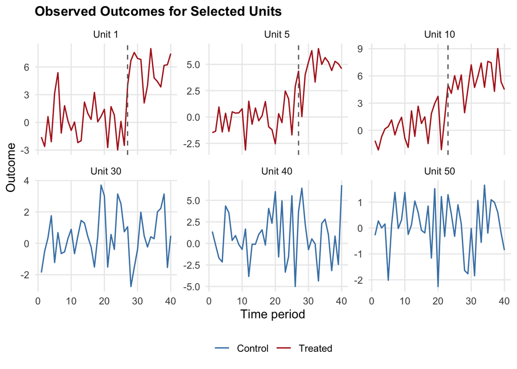

Observed outcomes for selected treated and control units. Vertical dashed lines indicate treatment adoption times.

```r
# ── Plot a few units ──
plot_units <- c(1, 5, 10, 30, 40, 50)
plot_data <- map_dfr(plot_units, function(i) {
  tibble(
    unit = factor(paste0("Unit ", i)),
    time = 1:T_total,
    outcome = example_data$Y_obs[i, ],
    treated = example_data$W[i, ] == 1,
    group = if (any(example_data$W[i, ] == 1)) "Treated" else "Control"
  )
})

treat_times <- tibble(
  unit = factor(paste0("Unit ", 1:N_treated)),
  treat_start = example_data$treat_start
)

ggplot(plot_data, aes(x = time, y = outcome, color = group)) +
  geom_line(linewidth = 0.6) +
  geom_vline(
    data = plot_data %>%
      filter(group == "Treated") %>%
      distinct(unit) %>%
      left_join(treat_times, by = "unit"),
    aes(xintercept = treat_start),
    linetype = "dashed", color = "gray40"
  ) +
  facet_wrap(~unit, scales = "free_y", ncol = 3) +
  scale_color_manual(values = c("Control" = "steelblue",
                                "Treated" = "firebrick")) +
  labs(
    x = "Time period",
    y = "Outcome",
    color = NULL,
    title = "Observed Outcomes for Selected Units"
  )
```

# Competing Estimators

We compare four methods. Each represents a different strategy for imputing counterfactuals.

## Method 1: Difference-in-Differences (DiD)

DiD estimates the counterfactual using unit and time fixed effects:
$$\hat{Y}_{it}(0)^{\text{DiD}} = \hat{\alpha}_i + \hat{\gamma}_t,$$
fitted on control observations.

```r
#' Two-way fixed effects DiD estimator for counterfactuals.
#'
#' @param Y_obs Observed outcome matrix.
#' @param W Treatment assignment matrix.
#' @return Matrix of estimated Y(0).
estimate_did <- function(Y_obs, W) {
  N <- nrow(Y_obs)
  T_total <- ncol(Y_obs)
  Y_control <- Y_obs
  Y_control[W == 1] <- NA

  # Unit means (from control periods only)
  alpha <- rowMeans(Y_control, na.rm = TRUE)
  # Time means (from control units only)
  gamma <- colMeans(Y_control, na.rm = TRUE)
  # Grand mean
  mu <- mean(Y_control, na.rm = TRUE)

  # Counterfactual: alpha_i + gamma_t - mu
  Y0_hat <- outer(alpha, rep(1, T_total)) +
    outer(rep(1, N), gamma) -
    mu
  Y0_hat
}
```

## Method 2: Synthetic Control via Re-weighting

For each treated unit, we find non-negative weights over control units that minimize the pre-treatment prediction error.

```r
#' Simplified synthetic control estimator.
#'
#' @param Y_obs Observed outcome matrix.
#' @param W Treatment assignment matrix.
#' @return Matrix of estimated Y(0).
estimate_sc <- function(Y_obs, W) {
  N <- nrow(Y_obs)
  T_total <- ncol(Y_obs)
  control_idx <- which(rowSums(W) == 0)
  treated_idx <- which(rowSums(W) > 0)

  Y0_hat <- Y_obs  # start with observed values

  for (i in treated_idx) {
    pre_periods <- which(W[i, ] == 0)
    post_periods <- which(W[i, ] == 1)

    if (length(pre_periods) < 2) next

    # Pre-treatment outcomes for treated unit
    y_pre <- Y_obs[i, pre_periods]
    # Pre-treatment outcomes for control units
    X_pre <- Y_obs[control_idx, pre_periods, drop = FALSE]

    # Solve for weights using constrained least squares (simplified)
    # w >= 0, sum(w) = 1
    # Use OLS projection then normalize (approximation)
    n_donors <- length(control_idx)
    w <- tryCatch({
      fit <- lm.fit(t(X_pre), y_pre)
      coefs <- fit$coefficients
      coefs[coefs < 0] <- 0
      if (sum(coefs) > 0) coefs / sum(coefs) else rep(1 / n_donors, n_donors)
    }, error = function(e) rep(1 / n_donors, n_donors))

    # Impute counterfactual
    Y0_hat[i, post_periods] <- as.numeric(w %*% Y_obs[control_idx, post_periods])
  }

  Y0_hat
}
```

## Method 3: Interactive Fixed Effects (IFE)

We estimate a rank-$K$ factor model on control observations only.

```r
#' Interactive fixed effects estimator via truncated SVD.
#'
#' @param Y_obs Observed outcome matrix.
#' @param W Treatment assignment matrix.
#' @param K Number of factors.
#' @return Matrix of estimated Y(0).
estimate_ife <- function(Y_obs, W, K = 3) {
  Y_control <- Y_obs
  Y_control[W == 1] <- NA

  Y_sparse <- as(Y_control, "Incomplete")

  # Use softImpute with a large lambda to get rank-K solution,
 # then refit with low lambda
  fit <- softImpute(Y_sparse, rank.max = K, lambda = 0.01, type = "svd")
  Y0_hat <- complete(Y_control, fit)
  Y0_hat
}
```

## Method 4: Matrix Completion (Nuclear Norm)

Our main method: soft-impute with cross-validated $\lambda$.

```r
#' Matrix completion estimator using soft-impute with block CV.
#'
#' @param Y_obs Observed outcome matrix.
#' @param W Treatment assignment matrix.
#' @param rank_max Maximum rank.
#' @return A list with Y0_hat and the selected lambda.
estimate_mc <- function(Y_obs, W, rank_max = 10) {
  Y_control <- Y_obs
  Y_control[W == 1] <- NA

  # Select lambda via block CV
  lambda_seq <- seq(0.1, 10, length.out = 20)
  cv_result <- tryCatch(
    block_cv_lambda(Y_control, W, lambda_seq, n_folds = 5,
                    rank_max = rank_max),
    error = function(e) list(lambda_best = 2)
  )

  Y_sparse <- as(Y_control, "Incomplete")
  fit <- softImpute(Y_sparse, rank.max = rank_max,
                    lambda = cv_result$lambda_best, type = "svd")
  Y0_hat <- complete(Y_control, fit)

  list(
    Y0_hat = Y0_hat,
    lambda = cv_result$lambda_best,
    rank = sum(fit$d > 1e-6)
  )
}
```

## Summary of Methods

Summary of competing estimators.

| Method | Key Assumption | Strategy | Tuning |
| --- | --- | --- | --- |
| DiD | Parallel trends (rank-2) | Unit + time fixed effects | None |
| Synthetic Control | Treated unit in convex hull of controls | Weighted combination of controls | Pre-treatment fit |
| Interactive FE | Exact low-rank factor model | Truncated SVD on controls | Number of factors K |
| Matrix Completion | Approximately low-rank | Nuclear norm regularization | Regularization lambda (CV) |

# Results

## Single Simulation: Counterfactual Recovery

We first illustrate how each method recovers the counterfactual for a single treated unit.

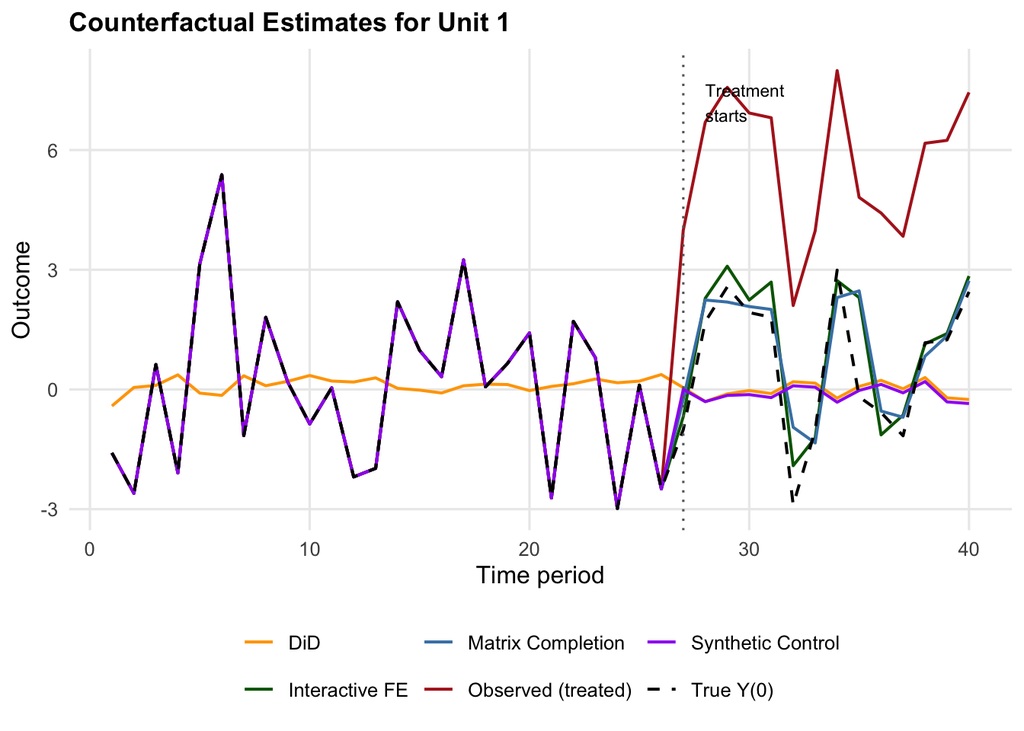

Counterfactual estimates for Unit 1. The black dashed line is the true Y(0); the red line is the observed (treated) outcome. Colored lines show each method’s estimate of the counterfactual.

```r
# ── Estimate counterfactuals with each method ──
did_hat <- estimate_did(example_data$Y_obs, example_data$W)
sc_hat <- estimate_sc(example_data$Y_obs, example_data$W)
ife_hat <- estimate_ife(example_data$Y_obs, example_data$W, K = 3)
mc_result <- estimate_mc(example_data$Y_obs, example_data$W)
mc_hat <- mc_result$Y0_hat

# ── Plot for Unit 1 ──
unit_i <- 1
t_start <- example_data$treat_start[unit_i]

unit_plot_data <- tibble(
  time = rep(1:T_total, 6),
  outcome = c(
    example_data$Y_obs[unit_i, ],
    example_data$Y0_true[unit_i, ],
    did_hat[unit_i, ],
    sc_hat[unit_i, ],
    ife_hat[unit_i, ],
    mc_hat[unit_i, ]
  ),
  method = rep(c("Observed (treated)", "True Y(0)",
                 "DiD", "Synthetic Control",
                 "Interactive FE", "Matrix Completion"),
               each = T_total)
)

ggplot(unit_plot_data, aes(x = time, y = outcome, color = method,
                           linetype = method)) +
  geom_line(linewidth = 0.7) +
  geom_vline(xintercept = t_start, linetype = "dotted", color = "gray40") +
  scale_color_manual(values = c(
    "Observed (treated)" = "firebrick",
    "True Y(0)" = "black",
    "DiD" = "orange",
    "Synthetic Control" = "purple",
    "Interactive FE" = "darkgreen",
    "Matrix Completion" = "steelblue"
  )) +
  scale_linetype_manual(values = c(
    "Observed (treated)" = "solid",
    "True Y(0)" = "dashed",
    "DiD" = "solid",
    "Synthetic Control" = "solid",
    "Interactive FE" = "solid",
    "Matrix Completion" = "solid"
  )) +
  labs(
    x = "Time period",
    y = "Outcome",
    color = NULL, linetype = NULL,
    title = "Counterfactual Estimates for Unit 1"
  ) +
  annotate("text", x = t_start + 1, y = max(unit_plot_data$outcome) * 0.9,
           label = "Treatment\nstarts", size = 3, hjust = 0)
```

## Monte Carlo Simulation

We now run 200 replications to compare methods on two metrics: (1) bias and RMSE of the ATT estimate, and (2) cell-level RMSE of counterfactual recovery.

```r
# ── Monte Carlo simulation ──
results <- map_dfr(seq_len(n_sim), function(sim) {

  data <- generate_panel(N, T_total, K_true, sigma_noise,
                         tau_true, N_treated)

  # Estimate counterfactuals
  did <- estimate_did(data$Y_obs, data$W)
  sc <- estimate_sc(data$Y_obs, data$W)
  ife <- estimate_ife(data$Y_obs, data$W, K = 3)
  mc <- tryCatch(
    estimate_mc(data$Y_obs, data$W)$Y0_hat,
    error = function(e) did  # fallback
  )

  # Treated cells
  treated_cells <- which(data$W == 1)

  # ATT estimates
  att_true <- data$tau_true
  methods_list <- list(
    DiD = did, `Synthetic Control` = sc,
    `Interactive FE` = ife, `Matrix Completion` = mc
  )

  map_dfr(names(methods_list), function(m) {
    Y0_hat <- methods_list[[m]]
    att_hat <- mean(data$Y_obs[treated_cells] - Y0_hat[treated_cells])
    cell_rmse <- sqrt(mean((Y0_hat[treated_cells] -
                              data$Y0_true[treated_cells])^2))
    tibble(
      sim = sim,
      method = m,
      att_hat = att_hat,
      att_bias = att_hat - att_true,
      cell_rmse = cell_rmse
    )
  })
}, .progress = FALSE)
```

### ATT Estimation

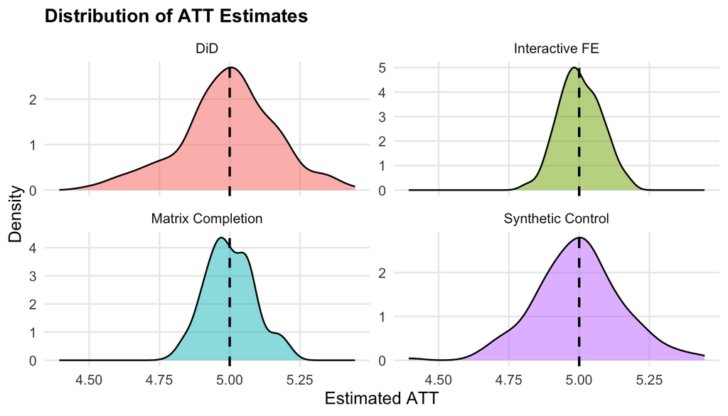

Distribution of ATT estimates across 200 simulations. The dashed vertical line marks the true ATT = 5.

```r
ggplot(results, aes(x = att_hat, fill = method)) +
  geom_density(alpha = 0.5) +
  geom_vline(xintercept = tau_true, linetype = "dashed", linewidth = 0.8) +
  facet_wrap(~method, ncol = 2, scales = "free_y") +
  labs(
    x = "Estimated ATT",
    y = "Density",
    title = "Distribution of ATT Estimates",
    fill = NULL
  ) +
  theme(legend.position = "none")
```

```r
att_summary <- results %>%
  group_by(method) %>%
  summarise(
    `Mean ATT` = mean(att_hat),
    Bias = mean(att_bias),
    SD = sd(att_hat),
    RMSE = sqrt(mean(att_bias^2)),
    .groups = "drop"
  ) %>%
  arrange(RMSE)

kable(att_summary, digits = 3, booktabs = TRUE,
      caption = "ATT estimation performance across 200 simulations.") %>%
  kable_styling(latex_options = "hold_position")
```

ATT estimation performance across 200 simulations.

| method | Mean ATT | Bias | SD | RMSE |
| --- | --- | --- | --- | --- |
| Interactive FE | 5.003 | 0.003 | 0.075 | 0.075 |
| Matrix Completion | 5.001 | 0.001 | 0.087 | 0.087 |
| Synthetic Control | 4.998 | -0.002 | 0.156 | 0.156 |
| DiD | 4.994 | -0.006 | 0.169 | 0.169 |

### Counterfactual Recovery

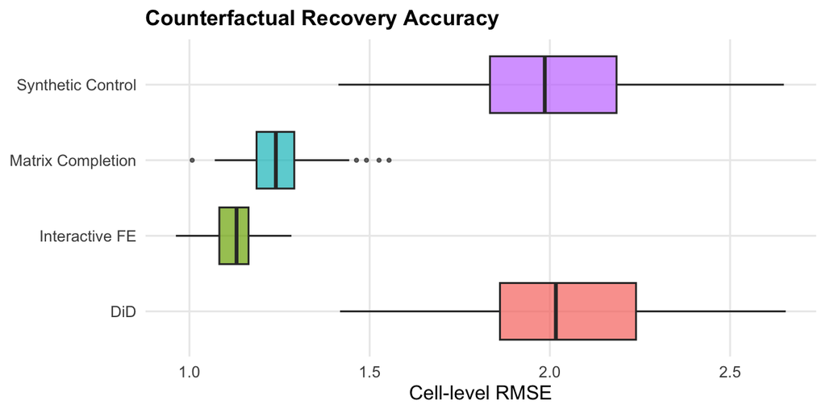

Cell-level RMSE of counterfactual recovery across 200 simulations.

```r
ggplot(results, aes(x = method, y = cell_rmse, fill = method)) +
  geom_boxplot(alpha = 0.7, outlier.size = 0.8) +
  labs(
    x = NULL,
    y = "Cell-level RMSE",
    title = "Counterfactual Recovery Accuracy"
  ) +
  theme(legend.position = "none") +
  coord_flip()
```

# Robustness: What Happens When Low-Rank Fails?

A fair evaluation must test the method outside its comfort zone. We now generate data where the true rank is high (rank 10) but we still fit matrix completion assuming low rank.

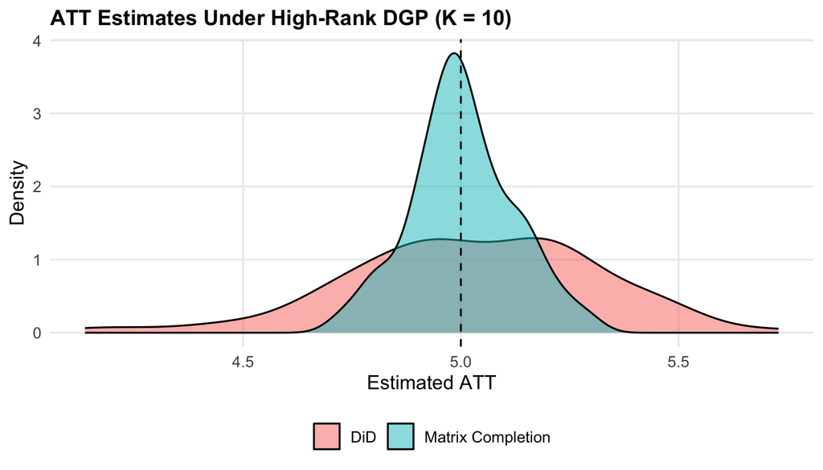

```r
results_highrank <- map_dfr(seq_len(100), function(sim) {

  data <- generate_panel(N, T_total, K_true = 10, sigma_noise = 1,
                         tau_true = 5, N_treated = 15)

  did <- estimate_did(data$Y_obs, data$W)
  mc <- tryCatch(
    estimate_mc(data$Y_obs, data$W, rank_max = 15)$Y0_hat,
    error = function(e) did
  )

  treated_cells <- which(data$W == 1)

  tibble(
    sim = sim,
    method = rep(c("DiD", "Matrix Completion"), each = 1),
    att_hat = c(
      mean(data$Y_obs[treated_cells] - did[treated_cells]),
      mean(data$Y_obs[treated_cells] - mc[treated_cells])
    ),
    att_bias = att_hat - 5
  )
}, .progress = FALSE)

ggplot(results_highrank, aes(x = att_hat, fill = method)) +
  geom_density(alpha = 0.5) +
  geom_vline(xintercept = 5, linetype = "dashed") +
  labs(
    x = "Estimated ATT",
    y = "Density",
    title = "ATT Estimates Under High-Rank DGP (K = 10)",
    fill = NULL
  )
```

# Strengths, Limitations, and Practical Guidance

## Strengths

Matrix completion offers several advantages over traditional causal panel data methods. First, it provides a **unifying framework**: DiD (rank-2), synthetic control (row space restriction), and interactive fixed effects (exact rank-$K$) are all special cases or close relatives. Matrix completion with nuclear norm regularization nests these approaches in a single, tunable estimator.

Second, it **does not rely on the standard DiD parallel-trends assumption**. Instead, it replaces that assumption with a low-rank structure assumption on untreated potential outcomes. When the underlying factor structure is richer than rank-2—for example, when different units respond differently to common economic shocks—DiD is misspecified, but matrix completion can still recover the counterfactual under its own (different) assumptions.

Third, it **handles staggered adoption naturally**. Unlike synthetic control, which is designed for a single treated unit, matrix completion can simultaneously impute counterfactuals for multiple units treated at different times.

Fourth, the optimization problem is **convex**, so the solution is unique and can be computed efficiently via soft-impute.

## Limitations

The method also has important limitations.

**Formal inference is difficult.** Standard errors and confidence intervals for the ATT under nuclear norm regularization are an active area of research. Unlike DiD, where asymptotic theory is well-developed, matrix completion currently lacks convenient inferential tools for practitioners. Bootstrap methods are possible but computationally expensive.

**Cross-validation requires care.** Random entry-level hold-out is invalid; block hold-out must mimic the treatment assignment pattern. Poor CV design leads to poor $\lambda$ selection and biased estimates.

**Tuning sensitivity.** The estimator depends on the choice of $\lambda$ and the maximum rank. In finite samples, results can be sensitive to these choices.

**No improvement in identification.** Matrix completion does not solve confounding. If treatment assignment depends on potential outcomes in ways not captured by the observed panel structure, the estimator is biased regardless of the imputation quality. The method improves *estimation* under appropriate structural assumptions, not *identification*.

## Practical Guidance

**When to use matrix completion:**

- You have panel data with multiple treated and control units over many time periods.
- Staggered adoption makes simple DiD awkward.
- You suspect the factor structure is richer than what parallel trends allows.
- You have enough control units and pre-treatment periods for the low-rank structure to be recoverable.

**When to prefer alternatives:**

- Only one treated unit with a clear donor pool: synthetic control may be simpler and more transparent.
- Parallel trends is plausible and you want well-understood inference: two-way fixed effects DiD.
- You have strong prior knowledge about the number of factors: interactive fixed effects with $K$ specified.
- Sample size is very small ($N < 10$ or $T < 10$): low-rank imputation may not have enough data to work with.

## A Minimal Workflow for Real Data

A researcher who wants to apply matrix completion to their own panel data can follow five steps.

**Step 1: Put the data in panel form.** The data should have one row for each unit-time observation, with at least four variables: a unit identifier, a time variable, an outcome, and a treatment indicator.

**Step 2: Create the outcome matrix.** Convert the data into an $N \times T$ matrix, where rows are units and columns are time periods. Each entry is the observed outcome $Y_{it}$.

**Step 3: Hide treated post-treatment outcomes.** For cells where $W_{it} = 1$, set the outcome to `NA` before fitting matrix completion. These are the counterfactual cells we want to impute. Control and pre-treatment cells remain observed.

**Step 4: Fit soft-impute and choose $\lambda$.** Use block cross-validation rather than random cell-level cross-validation. The validation blocks should look like the actual causal problem: whole post-treatment blocks for pseudo-treated units.

**Step 5: Estimate the ATT.** After completing the matrix, compare the observed treated outcomes to their imputed untreated counterfactuals:
$$\hat{\tau}_{\text{ATT}} = \frac{1}{|\mathcal{M}|} \sum_{(i,t) \in
\mathcal{M}} \left[ Y_{it} - \hat{Y}_{it}(0) \right].$$

In practice, the most important diagnostics are: (1) pre-treatment fit—does the completed matrix match the observed data well in pre-treatment periods for treated units? (2) sensitivity to $\lambda$—do the results change substantially across nearby $\lambda$ values? (3) sensitivity to the maximum rank—does increasing `rank.max` change the estimates? (4) substantive plausibility of low rank—is it reasonable that the outcomes are driven by a small number of common factors?

```r
# ── Minimal applied workflow ──

# 1. Wide outcome matrix: rows = units, columns = time
Y_mat <- panel_data |>
  select(unit_id, time, outcome) |>
  pivot_wider(names_from = time, values_from = outcome) |>
  column_to_rownames("unit_id") |>
  as.matrix()

# 2. Wide treatment matrix with same dimensions
W_mat <- panel_data |>
  select(unit_id, time, treated) |>
  pivot_wider(names_from = time, values_from = treated) |>
  column_to_rownames("unit_id") |>
  as.matrix()

# 3. Hide treated cells to estimate untreated potential outcomes
Y_control <- Y_mat
Y_control[W_mat == 1] <- NA

# 4. Fit matrix completion (choose lambda via block CV; see block_cv_lambda above)
fit <- softImpute(
  as(Y_control, "Incomplete"),
  rank.max = 5,
  lambda = lambda_chosen,   # from block_cv_lambda()
  type = "svd"
)

Y0_hat <- complete(Y_control, fit)

# 5. ATT estimate
att_hat <- mean(Y_mat[W_mat == 1] - Y0_hat[W_mat == 1])
```

# Conclusion

This tutorial introduced matrix completion as a machine-learning approach to causal inference in panel data. The core insight is conceptually simple: the counterfactual outcomes for treated units are missing entries in a matrix, and if that matrix has approximately low-rank structure, we can fill them in using nuclear norm regularization and the soft-impute algorithm.

The practical value of the method lies in its generality: it unifies several classical causal panel data approaches under a single optimization framework, handles staggered treatment adoption, and can be implemented with existing software. Its main limitations—difficulty with inference, sensitivity to tuning, and reliance on low-rank structure—are active areas of methodological research.

# References

Abadie, A., Diamond, A., & Hainmueller, J. (2010). Synthetic control methods for comparative case studies: Estimating the effect of California’s tobacco control program. *Journal of the American Statistical Association*, 105(490), 493–505.

Athey, S., Bayati, M., Doudchenko, N., Imbens, G., & Khosravi, K. (2021). Matrix completion methods for causal panel data models. *Journal of the American Statistical Association*, 116(536), 1716–1730.

Bai, J. (2009). Panel data models with interactive fixed effects. *Econometrica*, 77(4), 1229–1279.

Candès, E. J., & Recht, B. (2009). Exact matrix completion via convex relaxation. *Foundations of Computational Mathematics*, 9(6), 717–772.

Mazumder, R., Hastie, T., & Tibshirani, R. (2010). Spectral regularization algorithms for learning large incomplete matrices. *Journal of Machine Learning Research*, 11, 2287–2322.

Xu, Y. (2017). Generalized synthetic control method: Causal inference with interactive fixed effects models. *Political Analysis*, 25(1), 57–76.